# Data Exploration and Visualization

Data Analytics for Finance

Caspar David Peter

peter@rsm.nl

Rotterdam School of Management, Accounting Department

# Before We Start…

## Before We Start…

### Assignment Release and Submission Schedule

| Assignment | Release | Deadline |
| --- | --- | --- |
| A1 | 11.02.2026 | 25.02.2026 |
| A2 | 11.02.2026 | 25.02.2026 |
| A3 | 18.02.2026 |  |
| A4 | 25.02.2026 |  |
| A5 | 04.03.2026 |  |
| A6 | 11.03.2026 |  |

**Important Note on Assignment Deadlines**

# Data Exploration and Visualization

## Data Exploration and Visualization

### Today’s Journey

- Why visualize? The power and peril
- Describing variables: Building blocks
- Design principles that matter
- Tables: The unsung hero

### Literature

- Huntington-Klein (2022) (Chapters 3 & 4)

## Data Exploration and Visualization

### Recap - Where did we leave things?

#### Last time: The Research Pipeline

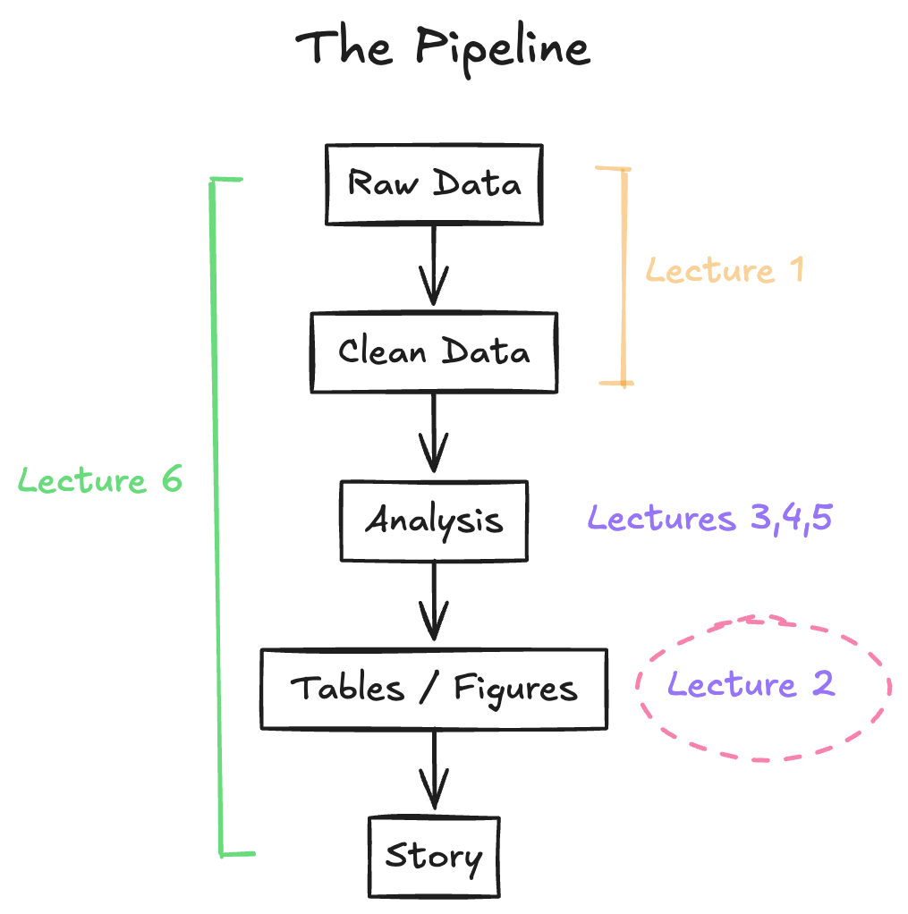

#### Raw & Clean Data

- Data acquisition (WRDS, identifiers)
- Merging datasets (CUSIP, GVKEY, PERMNO)
- Understanding and creating tidy data

##### Today’s Menu

- Data exploration & visualization
- Descriptive statistics
- Effective communication of results

> Today we learn how to LOOK at what we’ve built

## Data Exploration and Visualization

### Learning Objectives

#### By the end of today, you will be able to

- Explain why visualization matters for research AND practice
- Identify misleading visualizations and graph abuse
- Describe distributions and relationships effectively
- Apply core design principles to financial data
- Create publication-quality summary statistics tables

# Why Visualize? The Power and Peril

## Why Visualize? The Power and Peril

### Visualization in Practice

#### Just Eat Takeaway Analyst Presentation

[figure not shown]

#### What do you notice?

**Key observation**

Almost every slide contains a *visualization*!

**Key question**

Why do they do this?

Full presentation available here: [Just Eat Takeaway H1 2022 Results](https://s3.eu-central-1.amazonaws.com/takeaway-corporatewebsite-dev/Just-Eat-Takeaway.com-Analyst-Presentation-H1-2022.pdf)

## Visualization in Practice

### Growth Story

#### Gross Trsansaction Value Over Time

[figure not shown]

#### What story does this tell?

- “~2X growth since pre-pandemic”
- Clear trend, immediate impact
- Visual > table of numbers

What makes this effective?

- Clean design
- Clear annotation
- Color use to highlight key info

## Visualization in Practice

### Geographic Breakdown

#### Market Leadership Across Regions

[figure not shown]

#### Multiple dimensions in one view

- Geography
- Market position
- Revenue by segment

Cognitive efficiency?

- Would take paragraphs to describe in text
- [Latest disclosures](https://newsroom.justeattakeaway.com/en-WW/249197-just-eat-takeaway-com-q1-2025-trading-update/) before takeover by Prosus 🤦

## Visualization in Practice

### Comparative Performance

#### EBITDA by region over time

[figure not shown]

#### What does this show?

- Multiple entities (regions)
- Time dimension
- Positive vs. negative values
- Clear color coding

How long would this table be?

## Why Visualize? The Power and Peril

### The Case FOR Visualization

#### What is visualization (vis)?

> Computer-based visualization systems provide visual representations of **datasets** designed to help **people** carry out tasks more effectively (Munzner 2025).

#### Why visualize?

- **Communication**: Tell data-driven stories
- **Verification**: Confirm expected patterns
- **Exploration**: Find unexpected patterns
- **Falsification**: Assess validity of models

For more theory and details on visualization analysis and design, see Munzner (2025)

## Why Visualize? The Power and Peril

### But… Visualization Can Mislead

[figure not shown]

Source: [Washington Post, 2025](https://www.washingtonpost.com/technology/2025/08/12/gpt5-chart-crimes-claude-graphs/)

## Why Visualize? The Power and Peril

### But… Visualization Can Mislead

#### When keepin’ it vis goes wrong

##### OpenAI

[figure not shown]

##### Anthropic

[figure not shown]

## Why Visualize? The Power and Peril

### But… Visualization Can Mislead

#### When keepin’ it vis goes wrong

##### Pizza toppings in the UK

[figure not shown]

##### Female height distribution

[figure not shown]

## Why Visualize? The Power and Peril

### Insights from Beattie and Jones (1992)

#### The use and abuse of graphs in annual reports: theoretical framework and empirical study

- Study of 240 large UK companies’ annual reports
- Average: 5.9 graphs per report
- Key finding: Companies with ‘good’ performance significantly more likely to use graphs
- Selectivity: 65% graph at least one key financial variable
- But which variables do they choose?

## Why Visualize? The Power and Peril

### Two Forms of Distortion

#### Beattie and Jones (1992) Framework

#### Selectivity

Choosing WHICH data to visualize

- Graph the good news, table the bad news
- Example: Graph revenue growth, table margin decline

#### Measurement distortion

HOW data is presented

- Axis manipulation
- Visual exaggeration
- Found in 30% of graphs!
- Average exaggeration: 10.7%

## Why Visualize? The Power and Peril

### Distortion Example Overview

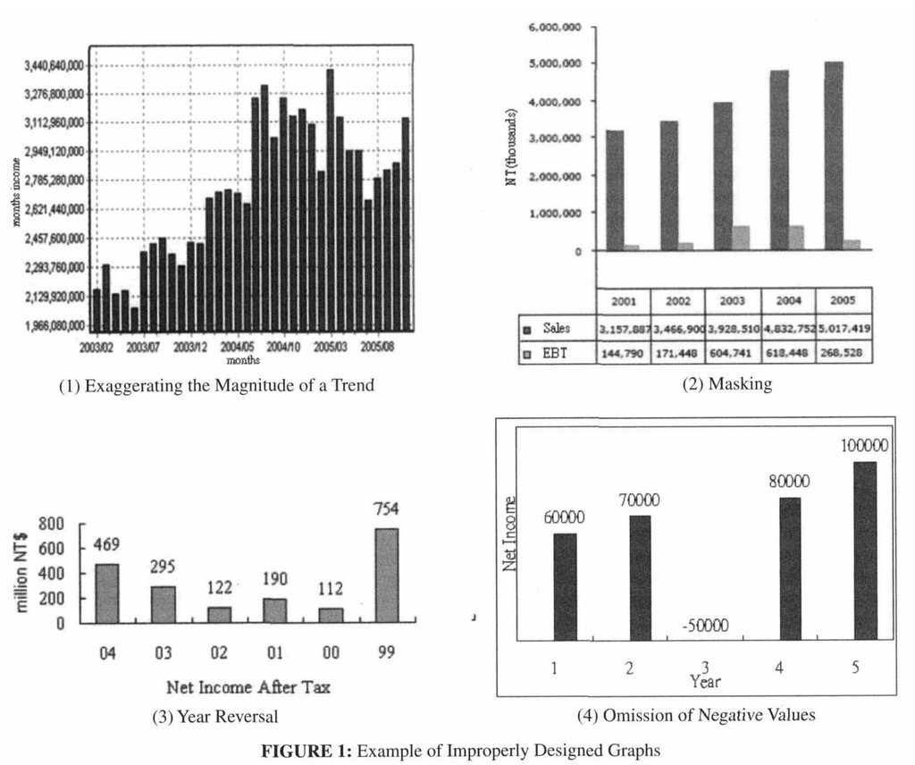

Source: Huang et al. (2011)

## Why Visualize? The Power and Peril

### Anscombe’s Quartet - The Famous Example

#### Identical Statistics, Different Stories

##### Anscombe’s Quartet Data

| Variable | N | Mean | SD | P0 | P25 | P50 | P75 | P100 |
| --- | --- | --- | --- | --- | --- | --- | --- | --- |
| x1 | 11 | 9.0 | 3.32 | 4.00 | 6.50 | 9.00 | 11.50 | 14.00 |
| y1 | 11 | 7.5 | 2.03 | 4.26 | 6.31 | 7.58 | 8.57 | 10.84 |
| x2 | 11 | 9.0 | 3.32 | 4.00 | 6.50 | 9.00 | 11.50 | 14.00 |
| y2 | 11 | 7.5 | 2.03 | 3.10 | 6.70 | 8.14 | 8.95 | 9.26 |
| x3 | 11 | 9.0 | 3.32 | 4.00 | 6.50 | 9.00 | 11.50 | 14.00 |
| y3 | 11 | 7.5 | 2.03 | 5.39 | 6.25 | 7.11 | 7.98 | 12.74 |
| x4 | 11 | 9.0 | 3.32 | 8.00 | 8.00 | 8.00 | 8.00 | 19.00 |
| y4 | 11 | 7.5 | 2.03 | 5.25 | 6.17 | 7.04 | 8.19 | 12.50 |

##### Visuals Matter

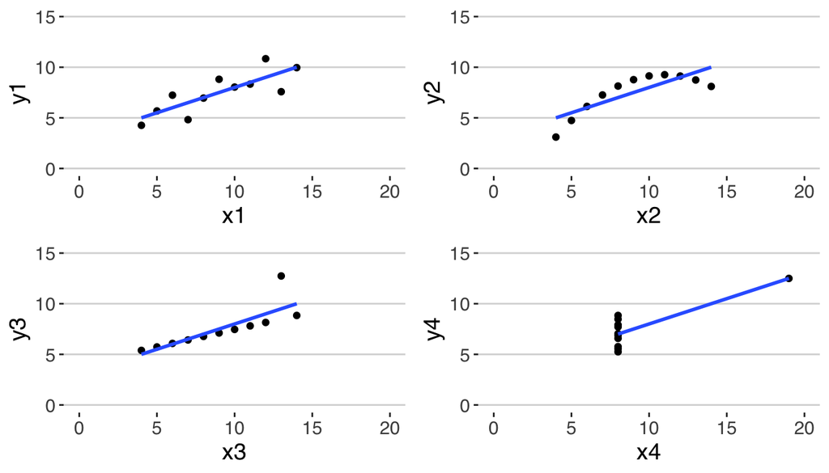

Visual inspection also reveals differences in variance, outliers, and non-linearity that summary statistics miss. Helpful for model (OLS) diagnostics! Wait for it, Lecture 3.

## Why Visualize? The Power and Peril

### Anscombe’s Quartet - The Famous Example

#### Key Takeaways

- Summaries lose information
- Details matter
- Visualization reveals structure that statistics hide

# Describing Variables: Building Blocks

## Describing Variables

### Types of Variables

#### What according to Munzner (2025)

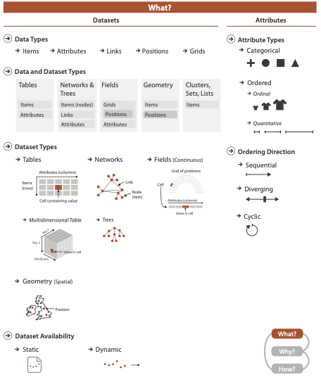

#### What we typically deal with…

- Continuous: Price, returns, income
- Count: Number of mergers, trades
- Ordinal: Credit ratings (AAA, AA, A…)
- Categorical: Industry, country
- Binary: Default/no default

Overview - Variables

## Describing Variables

### Understanding Distributions

#### Common Distribution Shapes

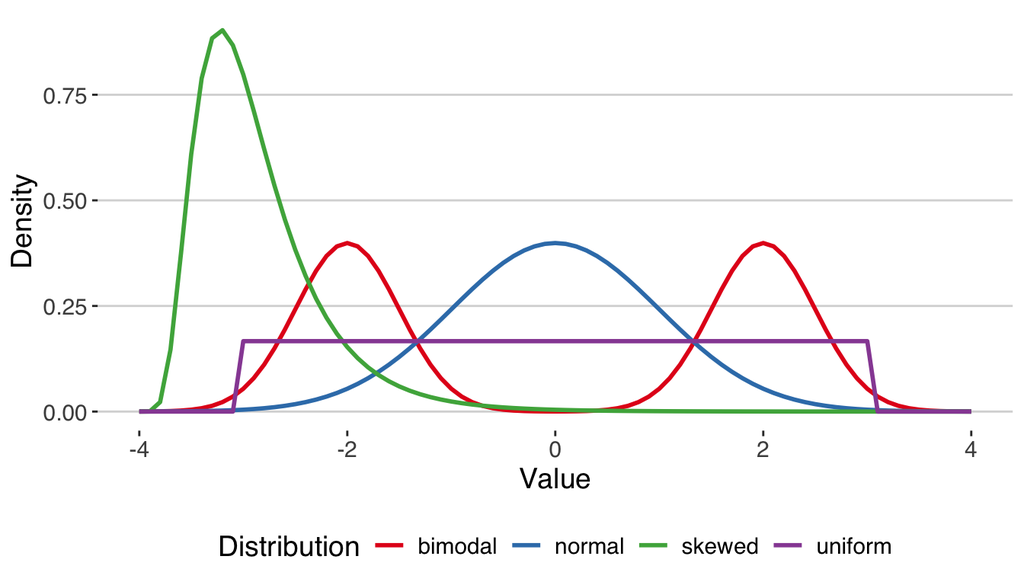

#### What is a distribution?

- The pattern of values a variable can take
- Key question: How is the data spread out?
- Examples:
  - Are most returns clustered around zero?
  - Do some firms have extremely high market caps?
  - Is income evenly distributed or skewed?

## Describing Variables

### Visualizing Distributions - Continuous Variables

#### Histograms

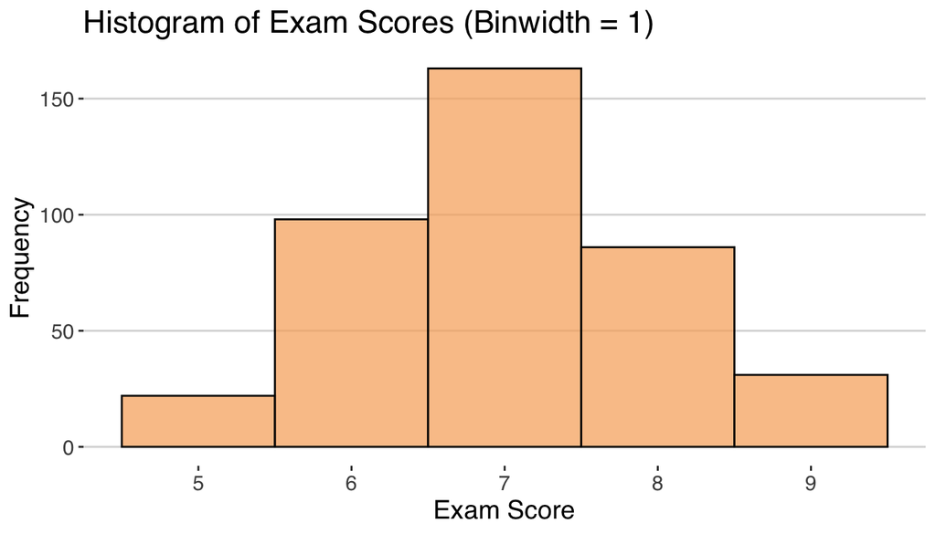

#### The Classic Choice

- Divides data into bins
- Height → frequency in each bin

## Describing Variables

### Visualizing Distributions - Continuous Variables

#### Histograms

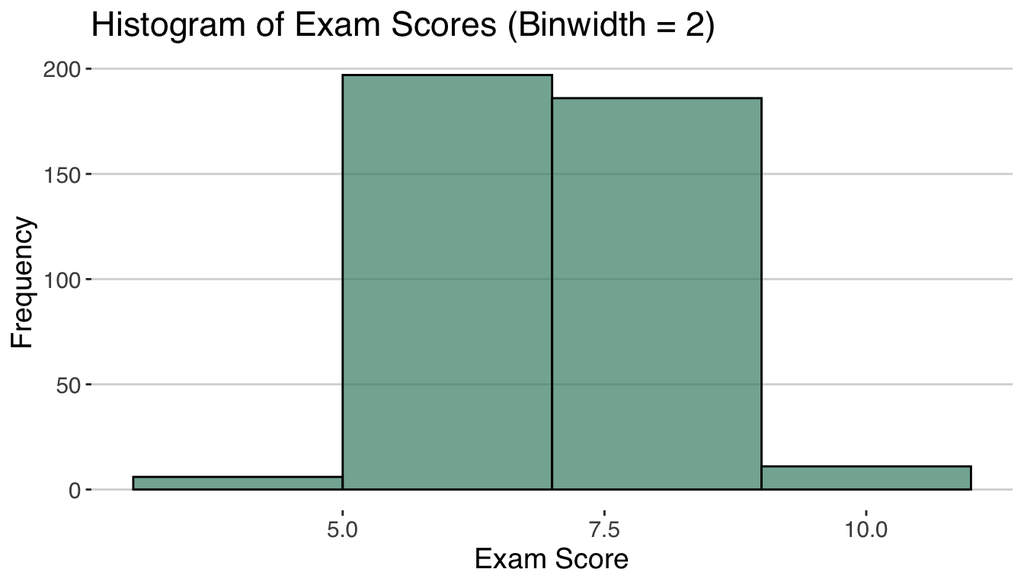

#### The Classic Choice

- Divides data into bins
- Height → frequency in each bin
- Design choices matter!:
  - Bin width too narrow → noise
  - Bin width too wide → oversmoothing

## Describing Variables

### Visualizing Distributions - Density Plots

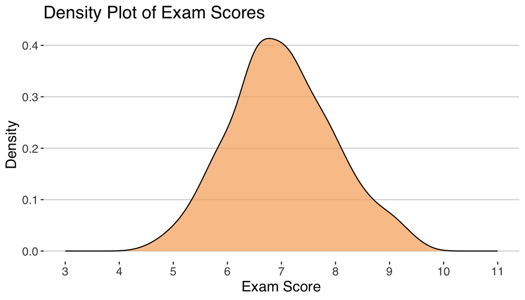

#### The Smooth Alternative

- Continuous curve estimate
- No arbitrary bin choices
- Easier to compare multiple distributions

## Describing Variables

### Visualizing Distributions - Density Plots

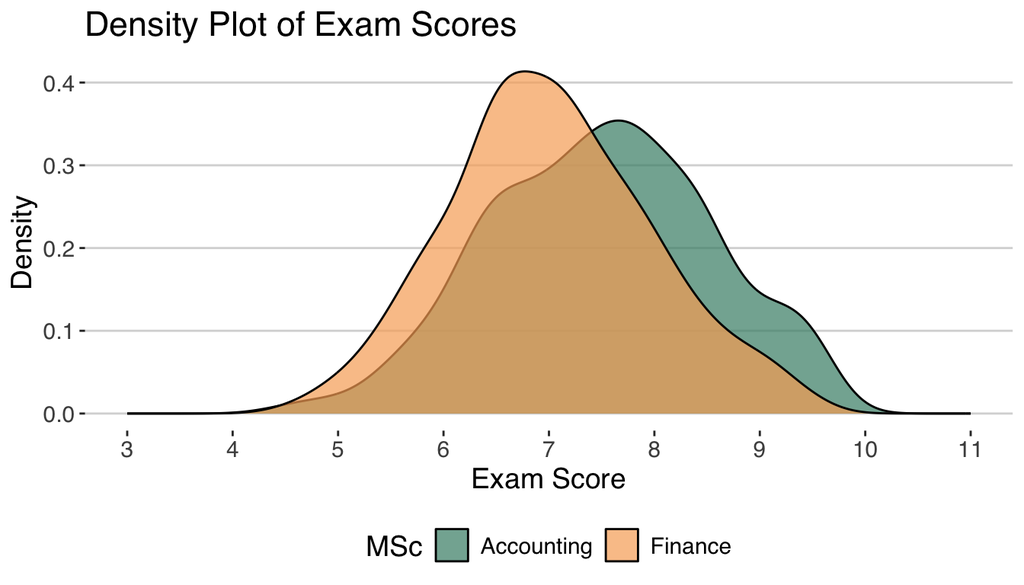

#### The Smooth Alternative

- Continuous curve estimate
- No arbitrary bin choices
- Easier to compare multiple distributions

## Describing Variables

### The Numbers Behind the Picture

#### Summary Statistics

##### Location (central tendency)

- Mean: Average value
- Median: 50th percentile
- Mode: Most frequent value

##### Spread (variability):

- Standard deviation: Distance from mean
- Variance: SD squared
- Range: Max - Min
- Interquartile range (IQR): Q3 - Q1

##### Percentile

→ value below which X% of observations fall

Examples:

- 25th percentile (Q1): Bottom quarter
- 50th percentile (Median): Middle
- 75th percentile (Q3): Top quarter
- 1st/99th percentile: Extreme values (outliers?)

##### Putting it all together (Box Plot)

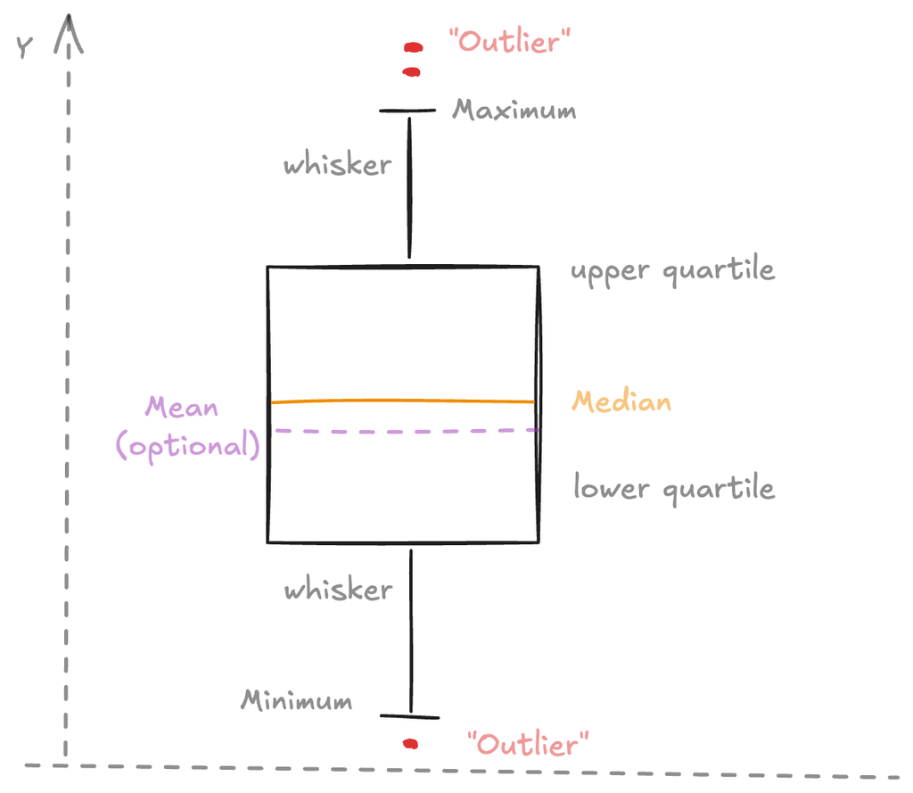

## Describing Variables

### Describing Relationships Between Variables

#### Moving Beyond Univariate Analysis

##### Key questions

- How do two variables move together?
- Is there a pattern?
- Is the relationship linear or nonlinear?

##### Tools

- Scatter plots
- Correlation
- Time series plots (for temporal relationships)

## Describing Variables

### Describing Relationships Between Variables

#### The Scatter Plot

#### Two Continuous Variables

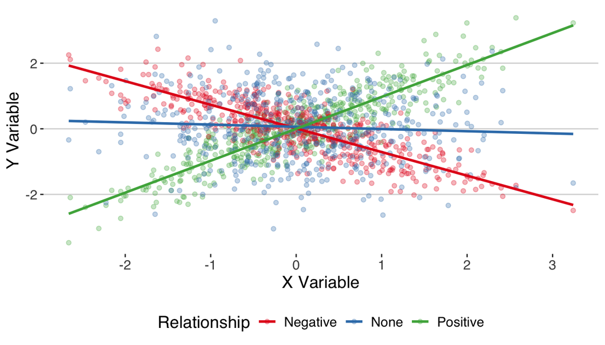

#### What to look for

- Direction (positive/negative)
- Strength (tight cluster vs. diffuse)
- Linearity (straight line or curve?)
- Outliers

## Describing Variables

### Describing Relationships Between Variables

#### Conditional Relationships

| Term | Meaning | Example |
| --- | --- | --- |
| Unconditional (or marginal) distribution | The overall spread of a variable, ignoring all other variables. | Height distribution of all children. |
| Conditional distribution | The spread of one variable **given** a specific value of another variable. | Distributions of vitamin E intake **among** those who exercise vigorously versus those who do not. |
| Unconditional mean | The average value of a variable, ignoring all other variables. | Average height of all children. |
| Conditional mean | The average value of a variable **given** a specific value of another variable. | Average vitamin E intake **among** those who exercise vigorously versus those who do not. |

Source: Adapted from Huntington-Klein (2022), Ch. 4

## Describing Variables

### Describing Relationships Between Variables

#### Correlation vs. Causation

##### Correlation vs. Causation

[figure not shown]

**The Most Important Distinction in Statistics**

- Correlation: X and Y move together
- Causation: X causes Y

More on that during Lecture 3 (identification)

## Describing Variables

### Describing Relationships Between Variables

### Time Series Plots

#### Daily Study Hours Over Time”

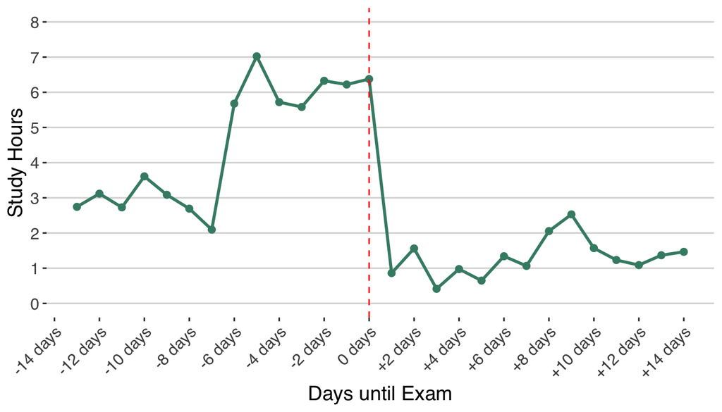

#### Basics of Time Series Plots

- X-axis: Time
- Y-axis: Variable of interest
- Connect the dots in chronological order

#### Essential for …

- Event studies (Lecture 5)
- (Parallel) Trend analysis (Lecture 4)
- Structural breaks
- Seasonality

## Describing Variables

### Describing Relationships Between Variables

#### Multiple Time Series - Comparison

##### VW vs. Competitors - TEASER A2

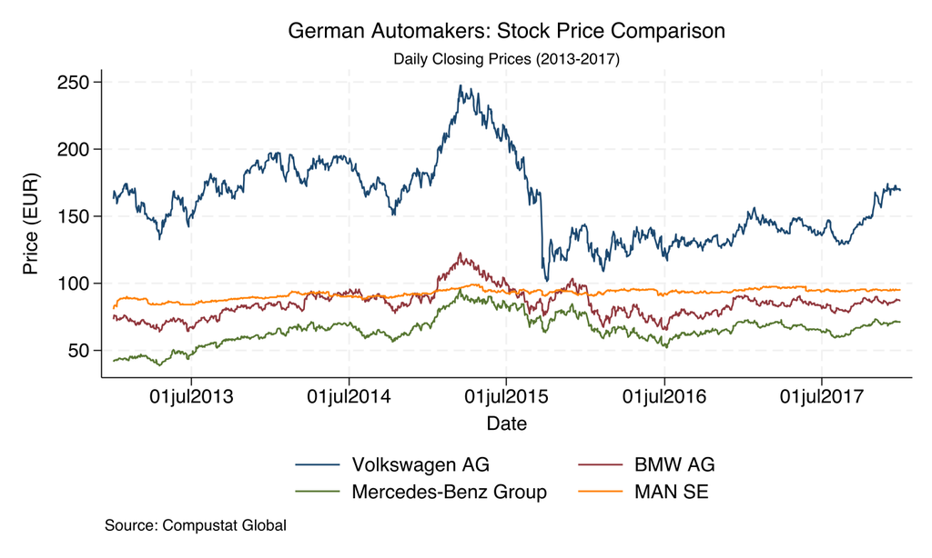

##### What this reveals

- Contagion effects
- Relative performance
- Industry-wide vs. firm-specific shocks

# Design Principles That Matter

## Design Principles That Matter

### Munzner (2025)’s Visualization Framework (Simplified)

#### Munzner (2025)

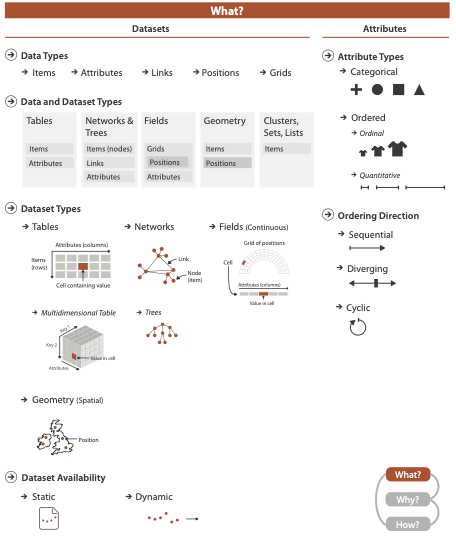

#### Three Important Questions

What? - What data do I have?

- Tables, networks, time series, spatial data
- We mostly work with: Tables (panel data)

## Design Principles That Matter

### Munzner (2025)’s Visualization Framework (Simplified)

#### Munzner (2025)

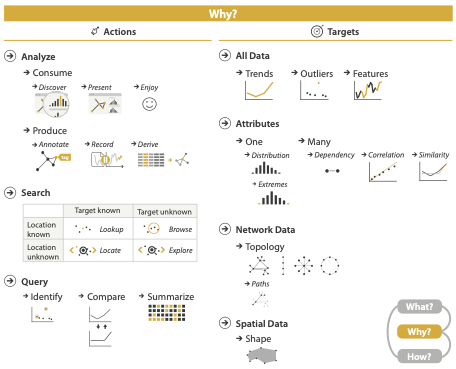

#### Three Important Questions

What? - What data do I have?

- Tables, networks, time series, spatial data
- We mostly work with: Tables (panel data)

Why? - Why am I visualizing?

- Communication, exploration, verification

## Design Principles That Matter

### Munzner (2025)’s Visualization Framework (Simplified)

#### Munzner (2025)

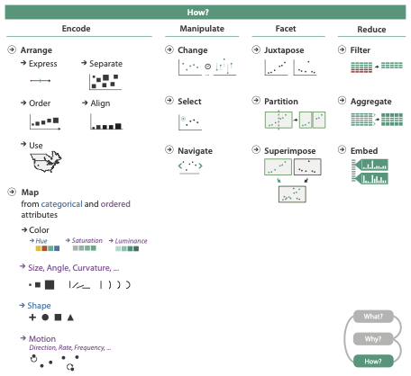

#### Three Important Questions

What? - What data do I have?

- Tables, networks, time series, spatial data
- We mostly work with: Tables (panel data)

Why?- Why am I visualizing?

- Communication, exploration, verification

How? - How should I encode the data?

- Position, color, size, shape

## Design Principles That Matter

### The Data-Ink Ratio

#### Edward Tufte’s Core Principle

$$\text{Data-ink ratio} = \frac{\text{ink used to display data}}{\text{total ink used}}$$

##### Goal: Maximize this ratio

- Remove chart junk
- Eliminate non-data ink
- Let the data speak

##### Example

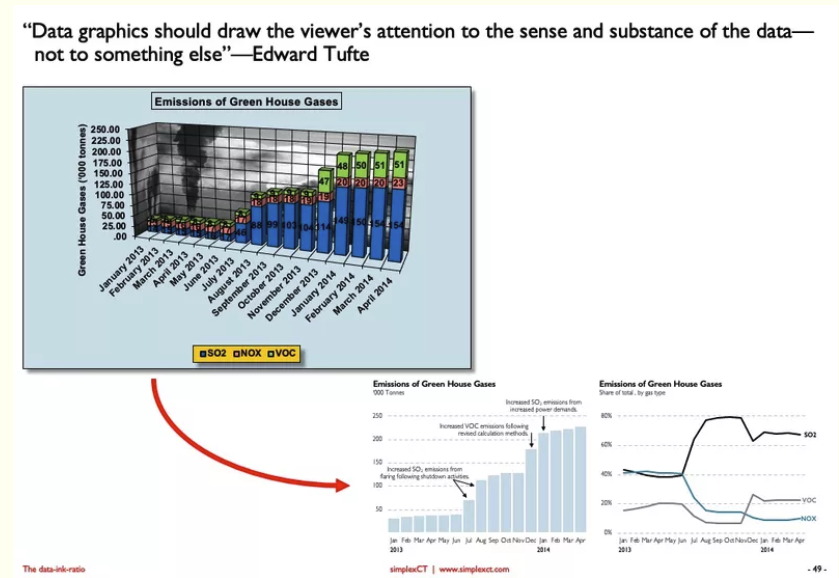

[Source](https://simplexct.com/data-ink-ratio)

## Design Principles That Matter

### Choosing the Right Plot Type

#### Match Visualization to Data Structure

| Data Structure | Best Visualization |
| --- | --- |
| One continuous variable | Histogram, density plot, box plot |
| One categorical variable | Bar chart |
| Two continuous variables | Scatter plot |
| Continuous over time | Line plot |
| Multiple groups over time | Line plot or small multiples |
| Part-to-whole | Stacked bar (avoid pie charts!) |

Overview - Plots

This is a simplified reference guide for your convenience; real-world data may require hybrid approaches.

## Design Principles That Matter

### Color Theory Basics

#### Strategic Use of Color

##### Three palette types:

1. **Sequential**: Light to dark (e.g., revenue growth)
2. **Diverging**: Two-color scale with neutral middle (e.g., positive/negative returns)
3. **Categorical**: Distinct colors for groups (e.g., different firms)

**Rule**

Use color to enhance, not decorate

## Design Principles That Matter

### Accessibility - Colorblind Considerations

#### ~8% of men have color vision deficiency

- Avoid red-green combinations
- Use colorblind-safe palettes:
  - Viridis (sequential)
  - ColorBrewer (all types)

Make sure your visualizations are **interpretable by everyone**! (inclusivity matters)

## Design Principles That Matter

### Accessibility - Colorblind Considerations

#### ~8% of men have color vision deficiency

#### Avoid red-green combinations

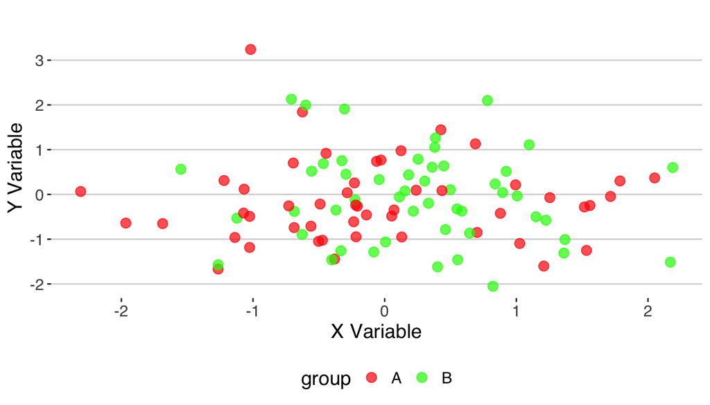

#### Use colorblind-safe palettes: Viridis

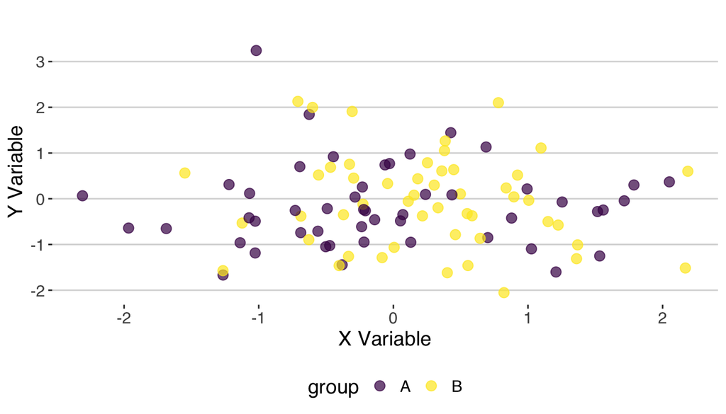

## Design Principles That Matter

### Axis Integrity

#### Y-axis should start at zero for bar charts

#### Exceptions

- Line plots (time series can start at sensible minimum)
- When showing small changes in large numbers
- **BUT**: Always be transparent about scale choices

#### Best practice

- Use non-zero axis when changes matter
- BUT: Clearly label and acknowledge the choice
- Never hide the axis range

## Design Principles That Matter

### Typography Matters

$$\text{Readable} > \text{Beautiful}$$

#### Font guidelines

- Minimum size: 8pt for print, 12pt for presentations
- Font families:
  - Sans-serif for plots (Arial, Helvetica)
  - Serif for text if desired (Times, Garamond)
- Consistency: Use same fonts throughout paper/presentation

#### Labels

- Axis labels: Clear, concise
- Title: Informative, standalone
- Legend: Only if necessary (prefer direct labels)

## Design Principles That Matter

### The Iteration Process

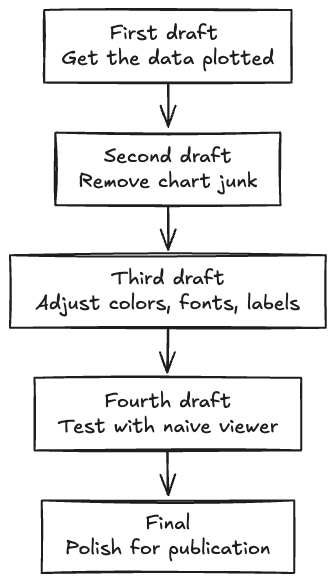

# Tables

Should be self-explanatory! Facts!

## Tables

### The Unsung Hero of Academic Communication

#### Tables are better when…

- Exact values matter (not just patterns)
- Many variables to compare
- Formal hypothesis testing results
- Standard format expected (e.g., regression output)

#### Plots are better when…

- Pattern matters more than precision
- Large amounts of data
- Relationships are key

## Tables

### The Unsung Hero of Academic Communication

#### Summary Statistics Table - Anatomy

##### Standard Format (imo)

| Variable | N | Mean | SD | Min | P25 | Median | P75 | Max |
| --- | --- | --- | --- | --- | --- | --- | --- | --- |

##### What this shows

- **N**: Sample size (are there missing values?)
- **Mean**: Central tendency
- **SD**: Dispersion
- **Min/Max**: Range (outliers?)
- **Percentiles**: Distribution shape

##### What to include

- Dependent variable(s)
- All other variables
- If panel data: Note firm-year structure
- **Notes** on data source, transformations, etc.
- Adhere to journal/MSc thesis style guide

## Tables

### Table Design Principles

#### Making Tables Readable

##### Alignment

- Numbers: Right-align
- Text: Left-align
- Headers: Center acceptable

##### Precision

- 2-3 decimal places usually sufficient
- Be consistent across columns
- Consistent between coefficients and fit stats

##### Formatting

- Use rules (horizontal lines) sparingly
- White space is your friend
- Bold for emphasis (e.g., column headers)

##### Notes

- Define variables
- Explain sample restrictions
- Note data sources

## Tables

### Table Design Principles

#### Example & Teaser for Assignment 6

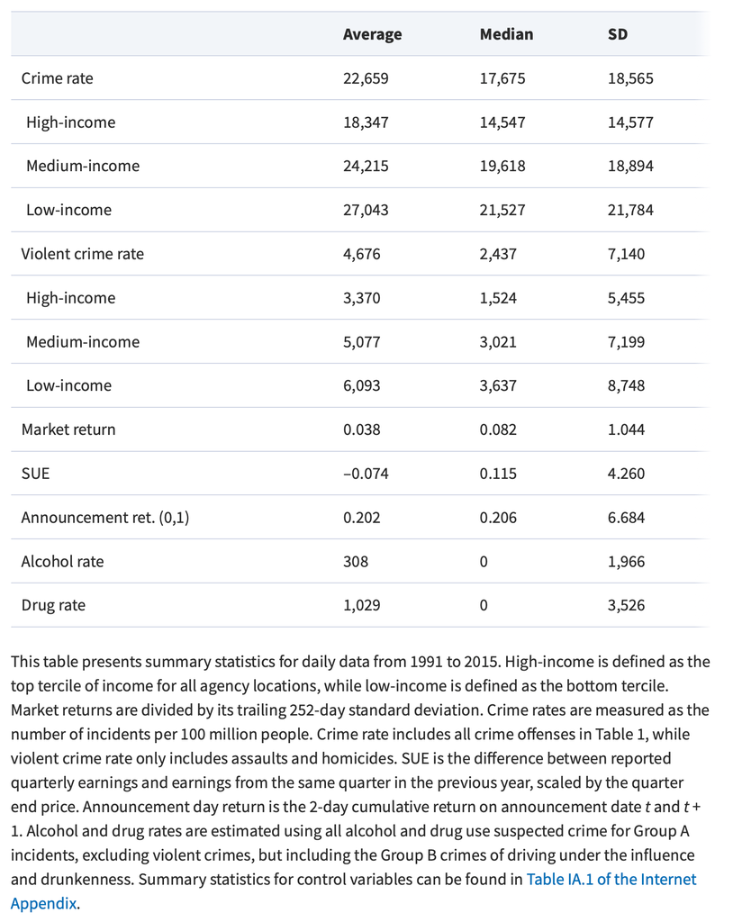

Huck (2024), Table 2

# Takeaways

## Takeaways

### What to Remember

- **Visualization is powerful** - for communication AND deception
- **Describe first, model later** - understand distributions and relationships
- **Design principles matter** - data-ink ratio, color, accessibility
- **Tables are essential** - especially in academic work
- **Iteration improves quality** - first draft is never the last draft

**The big picture**

**Good visualization** and tables are **core skills**, not optional extras.

# Teaser

## Next Week Preview

### Regression Methods and Identification

#### Building on today

- We can now DESCRIBE data
- Next: We learn to MODEL relationships
- OLS assumptions
- What is identification?
- Endogeneity and causation

#### The connection

- Today: “What does the data show?”
- Next week: “What does it mean?”

# JupyterHub - Walkthrough II

[JupyterHub](https://callisto.rsm.nl)

Thank You for Your Attention!

See You in the Next One!

## References

Beattie, Vivien, and Michael John Jones. 1992. “The Use and Abuse of Graphs in Annual Reports: Theoretical Framework and Empirical Study.” *Accounting and Business Research* 22 (88): 291–303.

Huang, Shaio-Yan, Shi-Ming Huang, Tung-Hsien Wu, and Tung-Yen Hsieh. 2011. “The Data Quality Evaluation of Graph Information.” *Journal of Computer Information Systems* 51 (4): 81–91.

Huck, John R. 2024. “The Psychological Externalities of Investing: Evidence from Stock Returns and Crime.” *The Review of Financial Studies* 37 (7): 2273–314.

Huntington-Klein, Nick. 2022. *The Effect: An Introduction to Research Design and Causality*. 2nd ed. Chapman; Hall/CRC.

Munzner, Tamara. 2025. “Visualization Analysis and Design.” *Proceedings of the Special Interest Group on Computer Graphics and Interactive Techniques Conference Courses*, 1–2.

Wilke, Claus O. 2019. *Fundamentals of Data Visualization: A Primer on Making Informative and Compelling Figures*. O’Reilly Media.